# Comprehensive Random Analysis of Covid-19

2023-01-24

This is a response to Adeline document about using random forest to explore the factors related to Covid-19. We liked the ideas included and hoped to extend it by exploreing specfic hypothisis about the question.

Hypothisis one: there is a linear relationship between N1 and cases. the covariates change the intercept of the relationship but there is always a base relationship.

```r
library(Covid19Wastewater)
library(dplyr)
```

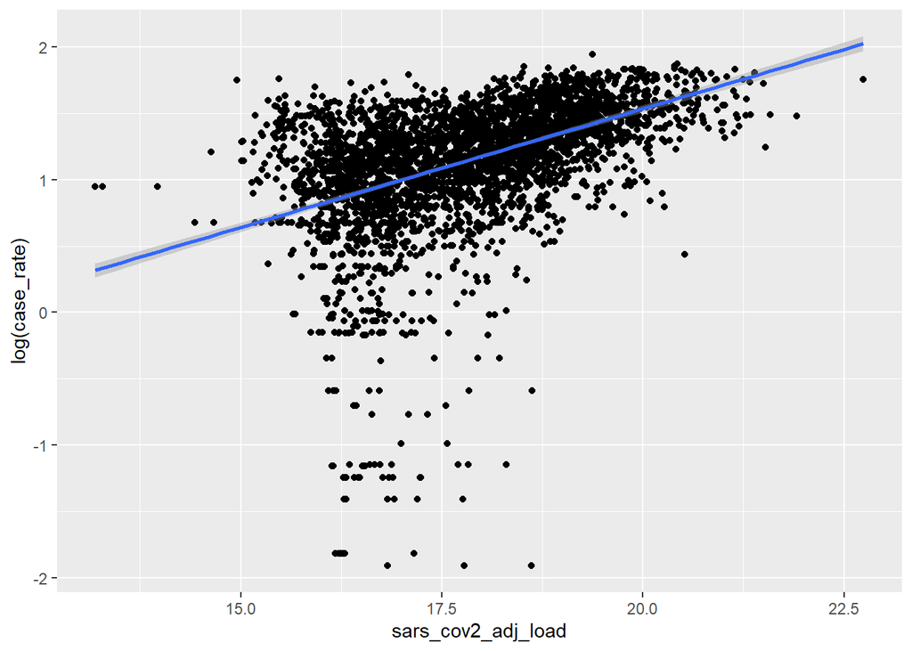

```r
library(ggplot2)
library(tidyr)
library(data.table)
load("../dhs_code/Normalization/data/data.H12.backup.RData")
'%!in%' <- function(x,y)!('%in%'(x,y))
'%!like%' <- function(x,y)!('%like%'(x,y))
data.H12<-data.H12.backup
### Prep H12 data
names(data.H12) <- c("wwtp_name", "epaid", "zipcode", "county_names", "state", "capacity_mgd", "population_served", "sample_type", "composite_freq", "sample_matrix", "sample_location", "sample_location_specify", "sample_id", "wwtp_comments", "concentration_method", "extraction_method", "pcr_type", "lod_ref", "quant_stan_type", "quant_stan_ref", "inhibition_method", "n1_sars_cov2_units", "n1_sars_cov2_conc", "n1_sars_cov2_lod", "n1_sars_cov2_error", "n1_ntc_amplify", "n1_num_ntc_amplify", "n1_num_no_target_control", "n1_lod", "n1_loq", "n2_sars_cov2_units", "n2_sars_cov2_conc", "n2_sars_cov2_lod", "n2_sars_cov2_error", "n2_ntc_amplify", "n2_num_ntc_amplify", "n2_num_no_target_control", "n2_lod", "n2_loq", "avg_sars_cov2_conc", "avg_sars_cov2_below_lod", "pmmov_conc", "hf183_conc", "bcov_rec_rate", "inhibition_detect", "inhibition_adjust", "analytical_comments", "sample_collect_date", "sample_collect_time", "test_result_date", "average_flow_rate", "equiv_sewage_amt", "tss", "ph", "bod", "conductivity", "temperature", "do", "bcov_spike_conc")

# Clean samples
data.H12 <- data.H12 %>% filter(wwtp_name %!like% "Madison-P")
data.H12 <- data.H12 %>% filter(wwtp_name %!in% c("Keshena", "Lac du Flambeau", "Menomonie", "Mondovi", "Neopit", "Red Cliff", "Wolf", "Wolf River"))
data.H12 <- data.H12 %>% filter(wwtp_name != "")

# Fix wwtp names
data.H12$wwtp_name <- gsub(" WWTP", "", data.H12$wwtp_name)
data.H12$wwtp_name <- gsub("WWTP", "", data.H12$wwtp_name)
data.H12$wwtp_name <- gsub("WWTF", "", data.H12$wwtp_name)
data.H12$wwtp_name <- gsub("BlackRiverFalls", "Black River Falls", data.H12$wwtp_name)
data.H12$wwtp_name <- gsub(" Metro", "", data.H12$wwtp_name)
data.H12$wwtp_name <- gsub("WI Rapids", "Wisconsin Rapids", data.H12$wwtp_name)
#print("List wwtps investigated (in H12 extract):")
#levels(as.factor(data.H12$wwtp_name))

# Add ID
data.H12$sample_collect_date<-as.Date(data.H12$sample_collect_date, format="%m/%d/%Y")
data.H12$ID<-paste0(data.H12$wwtp_name, data.H12$sample_collect_date)


data.meta<-read.table("../dhs_code/Normalization/data/WWDataRequestDNR.csv", sep = ",", h=T)
data.meta<-data.meta %>% filter(lab_submitter == "SLH")
### Preparation of metadata
# Fix wwtp names
data.meta$wwtp_name<-gsub(" WWTF", "", data.meta$wwtp_name)
data.meta$wwtp_name<-gsub(" WWTP", "", data.meta$wwtp_name)
data.meta$wwtp_name<-gsub(" Sewage Utility", "", data.meta$wwtp_name)
data.meta$wwtp_name<-gsub(" WW Utility", "", data.meta$wwtp_name)
data.meta$wwtp_name<-gsub(" Wastewater Utility", "", data.meta$wwtp_name)
data.meta$wwtp_name<-gsub(" WPCF", "", data.meta$wwtp_name)
data.meta$wwtp_name<-gsub(" MSD", "", data.meta$wwtp_name)
data.meta$wwtp_name<-gsub(" Utilities", "", data.meta$wwtp_name)
data.meta$wwtp_name<-gsub(" Municipal Utility", "", data.meta$wwtp_name)
data.meta$wwtp_name<-gsub(" Water Works", "", data.meta$wwtp_name)
#levels(as.factor(data.meta$wwtp_name))
#print("List wwtps with metadata (should be the same than above):")
#levels(as.factor(data.H12$wwtp_name))

# Add ID
data.meta$sample_collect_date <- as.Date(data.meta$sample_collect_date, format="%m/%d/%Y")
data.meta$ID <- paste0(data.meta$wwtp_name, data.meta$sample_collect_date)

# Metadata #1
data.meta.1 <- unique(data.meta[, c("ID", "sars_cov2_adj_load", "cases", "case_rate")])

# Metadata #2
data.meta.2 <- data.meta[, c("ID", "result_amt", "storet_parm_desc", "parm_unit_type")]
data.meta.2$storet_parm_desc <- gsub("CBOD5", "BOD5", data.meta.2$storet_parm_desc)
data.meta.2$storet_parm_desc <- gsub("BOD5, Total", "BOD5", data.meta.2$storet_parm_desc)
data.meta.2$storet_parm_desc <- gsub("Suspended Solids, Total", "TSS", data.meta.2$storet_parm_desc)
data.meta.2 <- reshape2::dcast(data.meta.2, ID~storet_parm_desc, value.var = "result_amt", fun.aggregate= function(x) if(length(x) == 0) NA_real_ else mean(x, na.rm = TRUE))
data.meta.2 <- data.meta.2 %>% select("ID", "BOD5", "Flow Rate", "TSS")

# Metadata - merged #1 and #2
data.meta <- left_join(data.meta.1, data.meta.2, by="ID")

data <- inner_join(data.H12, data.meta, by="ID")
#data<-data.H12

#data <-data %>% filter(pcr_type == "qPCR")

data$avg_sars_cov2_conc <- as.numeric(as.character(data$avg_sars_cov2_conc))
data$average_flow_rate <- as.numeric(as.character(data$average_flow_rate))
data$population_served <- as.numeric(as.character(data$population_served))
data$pmmov_conc <- as.numeric(as.character(data$pmmov_conc))
data$hf183_conc <- as.numeric(as.character(data$hf183_conc))
data$bcov_rec_rate <- as.numeric(as.character(data$bcov_rec_rate))
data$tss <- as.numeric(as.character(data$tss))
data$ph <- as.numeric(as.character(data$ph))
data$temperature <- as.numeric(as.character(data$temperature))
data$conductivity <- as.numeric(as.character(data$conductivity))
data$sars_cov2_adj_load <- as.numeric(as.character(data$sars_cov2_adj_load))
data$cases <- as.numeric(as.character(data$cases))
data$case_rate <- as.numeric(as.character(data$case_rate))
data$BOD5 <- as.numeric(as.character(data$BOD5))
data$`Flow Rate` <- as.numeric(as.character(data$`Flow Rate`))
data$TSS <- as.numeric(as.character(data$TSS))

data$wwtp_name <- as.factor(data$wwtp_name)

region_DF <- WasteWater_data%>%
  select(regions, site)%>%
  rename(wwtp_name = site)%>%
  mutate(regions = as.factor(regions))%>%
  unique()

model_data <- data%>%
  select(wwtp_name, pmmov_conc, bcov_rec_rate, average_flow_rate, ph,
         BOD5, TSS, sars_cov2_adj_load,#temperature
         case_rate)%>%
   left_join(region_DF)%>%
   select(-wwtp_name)%>%
  filter(case_rate != 0)%>%
  mutate(sars_cov2_adj_load = log(sars_cov2_adj_load),
         case_rate = log(case_rate))
model_data%>%
  ggplot(aes(x = sars_cov2_adj_load, y = log(case_rate)))+
  geom_point()+
  geom_smooth(method = "lm")
```

```r
lm_model = lm(log(case_rate) ~ sars_cov2_adj_load, data = model_data, na.action = na.exclude)
```

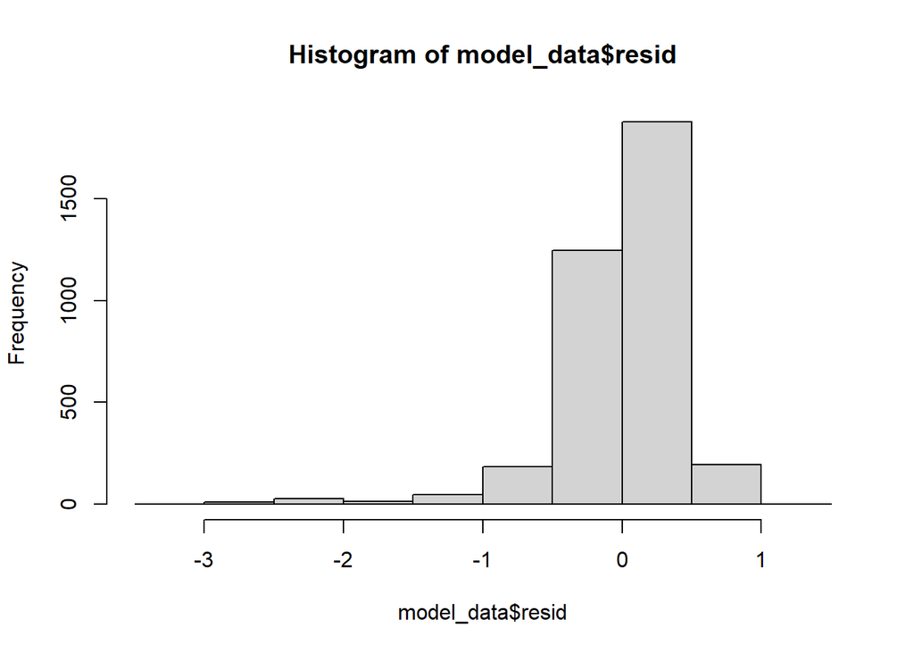

```r
model_data$resid = resid(lm_model)

hist(model_data$resid)
```

```r
base_df <- model_data%>%
  rename(conf_case = case_rate)
```

Given this conclusion we can fit these residuals into a random forest model to find what the intercept should be.

```r
library(randomForest)
rand_tree_df <- base_df%>%
  select(-conf_case, -sars_cov2_adj_load)%>%
   na.roughfix()%>%
   filter(if_all(everything(), is.finite))


rf.2 <-randomForest(resid~., data = rand_tree_df, ntree=100,
                    na.action = na.roughfix, importance=TRUE)
print(rf.2)
```

```
##
## Call:
##  randomForest(formula = resid ~ ., data = rand_tree_df, ntree = 100,      importance = TRUE, na.action = na.roughfix)
##                Type of random forest: regression
##                      Number of trees: 100
## No. of variables tried at each split: 2
##
##           Mean of squared residuals: 0.1432721
##                     % Var explained: 24.71
```

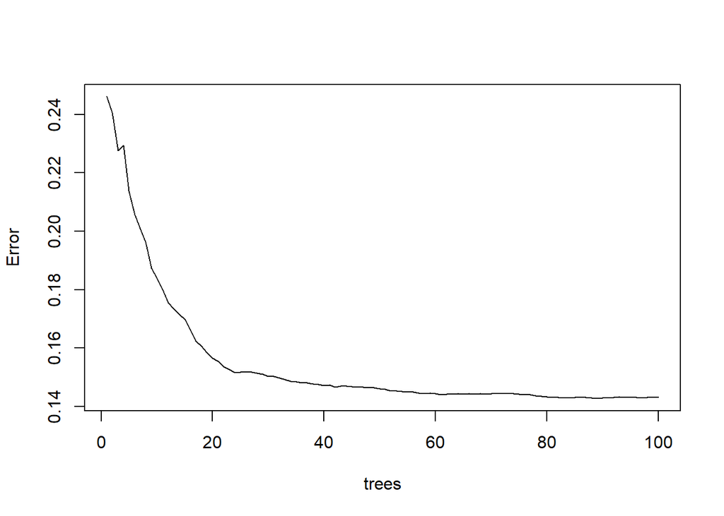

```r
plot(rf.2, type="l", main= "")
```

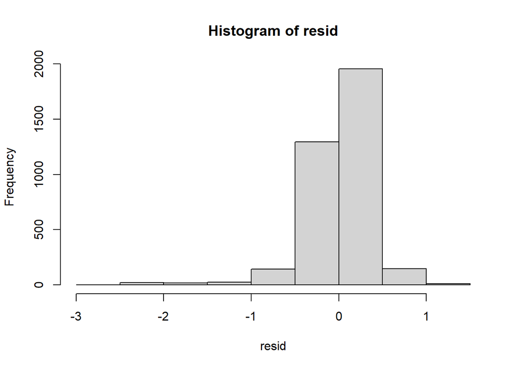

```r
pred = predict(rf.2)
resid = rand_tree_df$resid - pred
hist(resid)
```

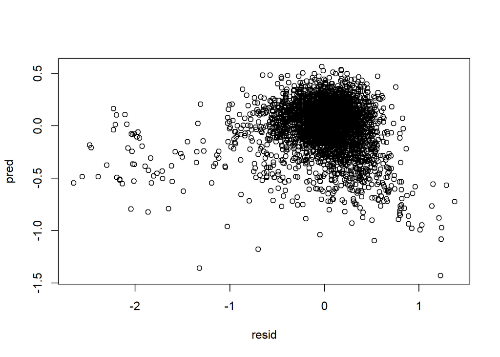

```r
plot(resid, pred)
```

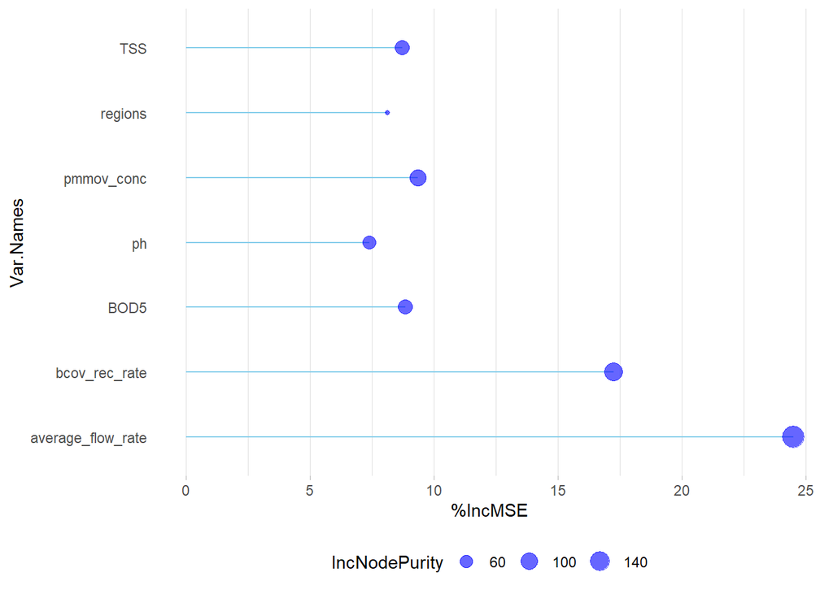

```r
ImpData <- as.data.frame(importance(rf.2))
ImpData$Var.Names <- row.names(ImpData)

ggplot(ImpData, aes(x=Var.Names, y=`%IncMSE`)) +
  geom_segment( aes(x=Var.Names, xend=Var.Names, y=0, yend=`%IncMSE`), color="skyblue") +
  geom_point(aes(size = IncNodePurity), color="blue", alpha=0.6) +
  theme_light() +
  coord_flip() +
  theme(
    legend.position="bottom",
    panel.grid.major.y = element_blank(),
    panel.border = element_blank(),
    axis.ticks.y = element_blank()
  )
```

This gives good results. but its assumption of a constant ratio does not match with what we expect of reality. depending on these factors we expect both a change in trend and a change in slope. This brings us to: s hypothsis 2: there is a linear relationship between N1 and cases. the covariates change the intercept and slope of the relationship.

```r
rand_tree_df <- base_df%>%
  select(-resid)%>%#,  -date, -tests
   na.roughfix()%>%
   filter(if_all(everything(), is.finite)) # N1 + N2

Form <- conf_case ~ sars_cov2_adj_load | . - sars_cov2_adj_load #N1 + N2
library(rsample)
forest_model <- random_linear_forest(data = rand_tree_df,
                                     num_tree = 100,
                  model_formula = Form,
                                     max_depth = Inf,
                  verbose = FALSE)

print(forest_model)
```

```
## [[1]]
## conf_case ~ sars_cov2_adj_load | . - sars_cov2_adj_load
##
## [[2]]
## [1] "size of data: 3617"
##
## [[3]]
## [1] "Number of trees: 100"
##
## [[4]]
## [1] "Mean of squared residuals: 0.695156312861101"
##
## [[5]]
## [1] "% Var explained: 56.6949687519164"
##
## attr(,"class")
## [1] "summary.random_linear_forest"
```

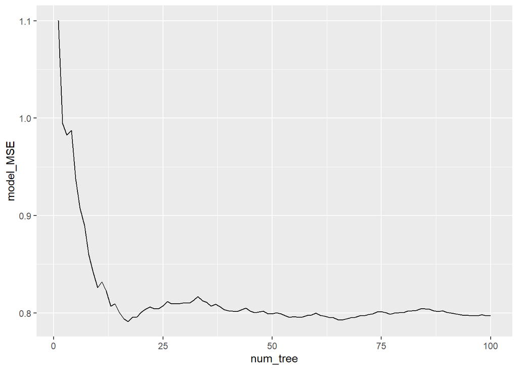

```r
oob_error_df <- OOB_MSE_num_trees(forest_model)
oob_error_df%>%
  ggplot(aes(y = model_MSE, x = num_tree))+
  geom_line()
```

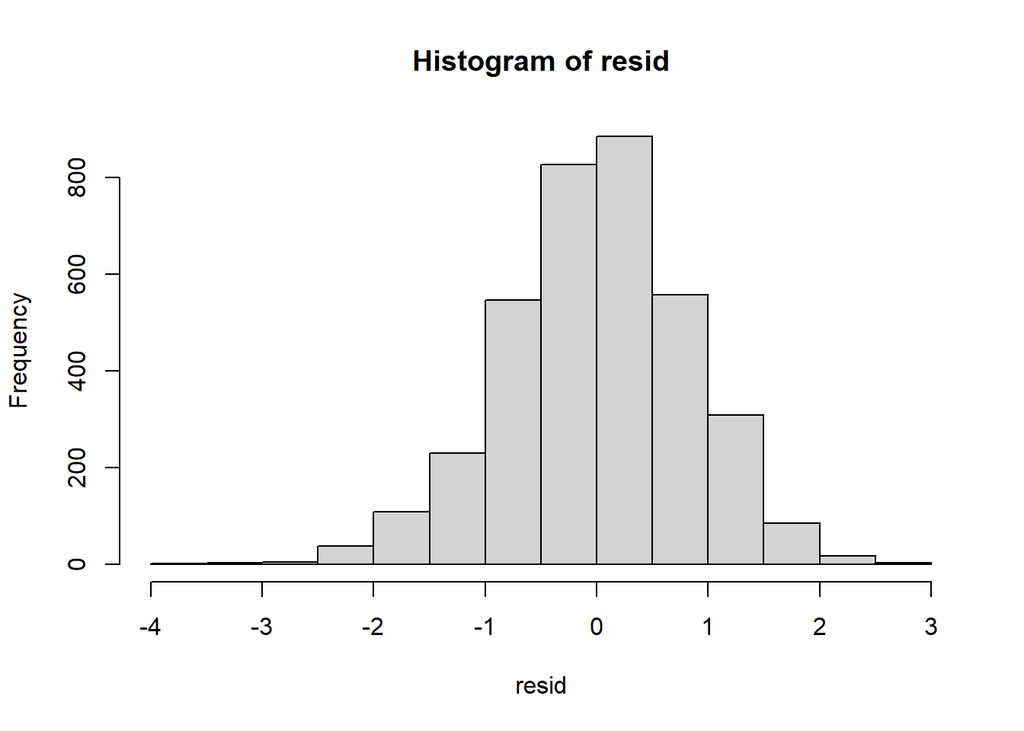

```r
#hist(rand_tree_df$conf_case - )
pred = predict(forest_model, rand_tree_df)
resid = rand_tree_df$conf_case - pred
hist(resid)
```

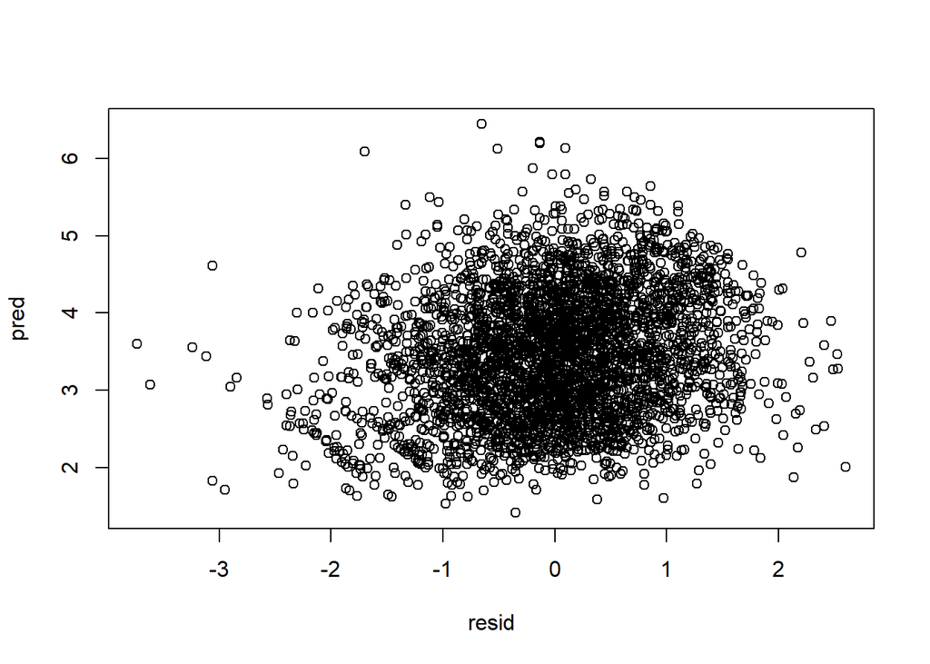

```r
plot(resid, pred)
```

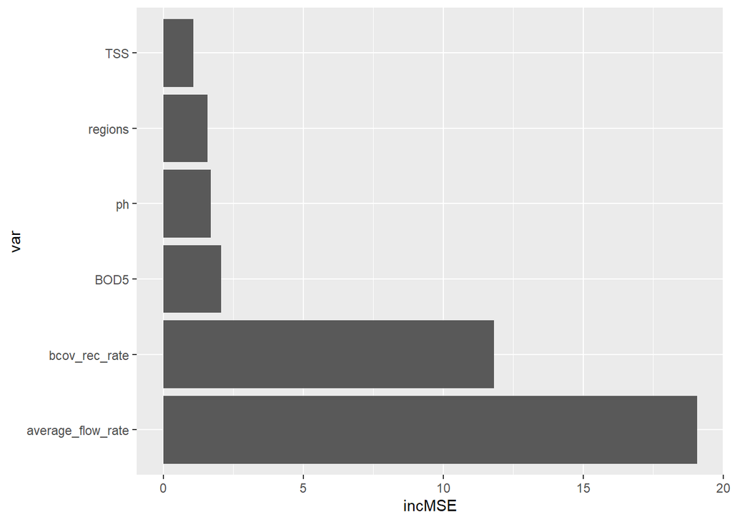

```r
inc_MSE <- gen_INCMSE(forest_model)
#reran model
#or
inc_MSE%>%
  ggplot(aes(y = var, x = incMSE))+
  geom_bar(stat="identity")
```

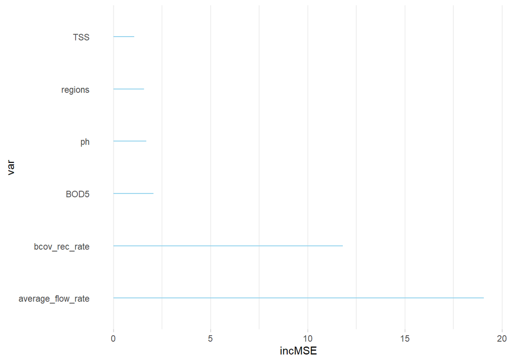

```r
ggplot(inc_MSE, aes(x = var, y = incMSE)) +
  geom_segment( aes(x=var, xend=var, y = 0, yend=incMSE), color="skyblue") +
  theme_light() +
  coord_flip() +
  theme(
    legend.position="bottom",
    panel.grid.major.y = element_blank(),
    panel.border = element_blank(),
    axis.ticks.y = element_blank()
)
```